# The impact of AI adoption on Canadian Wage - Subtopic 3: Education Levels

## *How has representation in AI-related occupations changed from 2012 to 2024 across different education levels?*

## Goals

The purpose of this analysis is to investigate how different education groups are represented in AI-related jobs across Canada.

- Load and combine Labour Force Survey (LFS) data from 2012 to 2024 for analysis.
- Clean the data to ensure key variables (education levels, occupation, weights) are valid and usable.
- Group education codes into meaningful categories for analysis.
- Filter the dataset to include only AI-related occupations.
- Calculate weighted representation of workers in AI-related occupations by education level.
- Visualize trends over time and summarize average yearly representation to understand how education affects access to AI-related work in Canada.

## Introduction

**Context/Hypothesis:** As AI reshapes the Canadian workforce, workers with higher education, particularly post-secondary or technical degrees, are expected to be more represented in AI-related occupations than those with lower education levels.

## Problem Statement

We aim to answer the following question: How has representation in AI-related occupations changed from 2012 to 2024 across different education levels?

**Significance:** This research provides insights into how education impacts access to AI-related jobs in Canada, helping inform training programs, educational efforts, and workforce planning.

## Starting With The LFS Dataset/Initial Setup

In this section, we import the necessary Python packages for data handling, visualization, and analysis. These libraries will be used throughout the project for cleaning, transforming, exploring, and visualizing the data.

```python
# Import necessary packages for data analysis, visualization, and statistical tests
import pandas as pd
import glob
import os
from pathlib import Path
import numpy as np
import matplotlib.pyplot as plt
import seaborn as sns

# Adjust pandas and seaborn settings for better readability in the notebook
pd.set_option("display.max_columns", None)
pd.set_option("display.width", None)
sns.set(style="whitegrid")
```

## Transformation/Data Loading

In this section, we load the Labour Force Survey (LFS) data from CSV files. The dataset is stored in yearly folders (2012 to 2024), and each folder contains multiple monthly CSV files.

We will only load the columns needed for our analysis:

- REC_NUM: unique record identifier
- SURVYEAR: survey year
- EDUC: education level
- NOC_10: occupation code (used to identify AI-related jobs)
- FINALWT: survey weight for each respondent

```python
# Set path to LFS data folder
base_path = Path.home() / "Downloads" / "LFS_DATA"

# Columns to load from each CSV
usecols = ['REC_NUM', 'SURVYEAR', 'EDUC', 'NOC_10', 'FINALWT']

# Collect all monthly/yearly CSV files into a list
lfs_data_list = []

# Loop through each year and read all CSV files
for year in range(2012, 2025):
    year_folder = base_path / str(year)
    files = sorted(glob.glob(os.path.join(year_folder, "*.csv")))
    if not files:
        print(f"Year {year}: no files found in {year_folder}")
        continue

    for f in files:
        try:
            # Read only the required columns and ensure proper data types
            df = pd.read_csv(f, usecols=usecols, dtype={'NOC_10': float, 'EDUC': float}, low_memory=False)
            # Append the DataFrame to the list
            lfs_data_list.append(df)
        except Exception as e:
            print(f"Could not read {f}: {e}")

# Combine all files into a single DataFrame
lfs = pd.concat(lfs_data_list, ignore_index=True)
print("Combined LFS shape:", lfs.shape)

# Preview the first 5 rows to verify the dataset loaded correctly
lfs.head()
```

```
Combined LFS shape: (15888230, 5)
```

|  | REC_NUM | SURVYEAR | EDUC | NOC_10 | FINALWT |
| --- | --- | --- | --- | --- | --- |
| 0 | 1 | 2012 | 1.0 | 7.0 | 198 |
| 1 | 2 | 2012 | 1.0 | NaN | 124 |
| 2 | 3 | 2012 | 2.0 | NaN | 108 |
| 3 | 4 | 2012 | 4.0 | 7.0 | 106 |
| 4 | 5 | 2012 | 4.0 | 8.0 | 860 |

## Data Cleaning: Handling Missing Values and Data Types

This section prepares the Labour Force Survey (LFS) data for analysis by ensuring that key variables are complete and correctly formatted. Since the research question focuses on education levels and AI-related occupations over time, education codes, occupation codes, survey year, and survey weights must contain valid values.

First, we examine the proportion of missing values in the education level, occupation code, and survey weight variables.

Next, we convert occupation codes and survey weights to numeric formats to ensure they can be reliably filtered and used in weighted analyses.

Finally, we remove observations with missing values in essential variables, resulting in a cleaned dataset suitable for further transformation and analysis.

```python
# Examine missing data in key columns: education, occupation code, and survey weights
print("Missing EDUC:", lfs['EDUC'].isna().mean())
print("Missing NOC_10:", lfs['NOC_10'].isna().mean())
print("Missing FINALWT:", lfs['FINALWT'].isna().mean())

# Convert NOC_10 to integer (nullable Int64) for easier filtering
lfs['NOC_10_int'] = pd.to_numeric(lfs['NOC_10'], errors='coerce').astype('Int64')

# Ensure FINALWT is numeric
lfs['FINALWT'] = pd.to_numeric(lfs['FINALWT'], errors='coerce')

# Remove rows missing EDUC, SURVYEAR, or FINALWT as these are required for analysis
lfs = lfs.dropna(subset=['EDUC', 'FINALWT', 'SURVYEAR'])
lfs['EDUC'] = pd.to_numeric(lfs['EDUC'], errors='coerce')
lfs = lfs.dropna(subset=['EDUC'])

print("After dropping key missings:", lfs.shape)
```

```
Missing EDUC: 0.0
Missing NOC_10: 0.3300975627870442
Missing FINALWT: 0.0
After dropping key missings: (15888230, 6)
```

## Data Transformation: Grouping Education Levels

In this step, the detailed ISCED education codes are transformed into broader, more understandable education categories. Grouping education levels makes it easier to compare across groups and aligns with our research question on representation by educational attainment.

A new variable, EDUC_GROUP, is created by mapping ISCED codes to categories such as Less Than High School, High School, Post-Secondary Non-Tertiary, Short-Cycle Tertiary, Bachelor’s, Master’s, and Doctorate. After creating this variable, we examine how observations are distributed across education groups to understand the structure of the cleaned dataset.

```python
# Map ISCED education codes to broader categories
def map_isced_to_group(isced):

    # Convert the value to an integer
    isced = int(isced)

    # Map codes to education groups
    if isced in [0, 1, 2]:
        return "Less Than High School"
    elif isced == 3:
        return "High School"
    elif isced == 4:
        return "Post-Secondary Non-Tertiary"
    elif isced == 5:
        return "Short-Cycle Tertiary"
    elif isced == 6:
        return "Bachelor's"
    elif isced == 7:
        return "Master's"
    elif isced == 8:
        return "Doctorate"
    elif isced == 9:
        return "Other"
    else:
        return "Other"

# Apply mapping
lfs['EDUC_GROUP'] = lfs['EDUC'].apply(map_isced_to_group)

# Display counts for each education group
display(
    lfs['EDUC_GROUP']
    .value_counts(dropna=False)
    .reset_index()
    .rename(columns={'EDUC_GROUP': 'Education Group', 'count': 'Count'})
)
```

|  | Education Group | Count |
| --- | --- | --- |
| 0 | Less Than High School | 6091036 |
| 1 | Post-Secondary Non-Tertiary | 5288648 |
| 2 | Short-Cycle Tertiary | 2390217 |
| 3 | Bachelor's | 1123455 |
| 4 | High School | 994874 |

## Filtering the Dataset to AI-Related Occupations

To address the research question, the analysis focuses specifically on AI-related occupations. Using the occupation classification (NOC_10), the dataset is filtered to retain only records corresponding to AI-related roles.

This filtered dataset (lfs_ai) represents the subset of workers employed in AI-related occupations. We report the total number of observations in the full dataset and the AI-related subset, and we examine the distribution of education levels within AI occupations. This step prepares the data for the exploratory analysis and trend comparisons over time.

```python
# Keep only NOC_10 code 2 (AI-related)
lfs_ai = lfs[lfs['NOC_10_int'].isin([2])].copy()
print("Total records:", len(lfs))
print("AI-related records:", len(lfs_ai))

# Display counts by education group in AI subset
display(
    lfs_ai['EDUC_GROUP']
    .value_counts(dropna=False)
    .reset_index()
    .rename(columns={'EDUC_GROUP': 'Education Group', 'count': 'Count'})
)
```

```
Total records: 15888230
AI-related records: 1529916
```

|  | Education Group | Count |
| --- | --- | --- |
| 0 | Post-Secondary Non-Tertiary | 619550 |
| 1 | Short-Cycle Tertiary | 347874 |
| 2 | Less Than High School | 340363 |
| 3 | Bachelor's | 122951 |
| 4 | High School | 99178 |

## EDA and Main Analysis: Yearly Representation in AI-Related Occupations

This section combines exploratory data analysis (EDA) with a detailed analysis to examine how representation in AI-related occupations has evolved over time across different education levels. Using survey weights from the Labour Force Survey (FINALWT), we compute weighted estimates that reflect population-level employment patterns.

First, weighted totals of all employed individuals and AI-related workers are calculated for each survey year and education group. These totals are used to derive the proportion of workers employed in AI-related occupations for every education level from 2012 to 2024. The results are first explored using a table, followed by a line plot to show trends and changes over time.

```
Yearly Representation By Education (weighted):
```

|  | SURVYEAR | EDUC_GROUP | Total_Weighted | AI_Weighted | Proportion_in_AI |
| --- | --- | --- | --- | --- | --- |
| 0 | 2012 | Bachelor's | 23570253 | 2880696 | 0.122217 |
| 1 | 2012 | High School | 25120836 | 2805956 | 0.111698 |
| 2 | 2012 | Less Than High School | 133181881 | 8619632 | 0.064721 |
| 3 | 2012 | Post-Secondary Non-Tertiary | 106345184 | 13464699 | 0.126613 |
| 4 | 2012 | Short-Cycle Tertiary | 50521079 | 7951066 | 0.157381 |
| 5 | 2013 | Bachelor's | 24447378 | 2782961 | 0.113835 |
| 6 | 2013 | High School | 24864211 | 2827946 | 0.113736 |
| 7 | 2013 | Less Than High School | 133754571 | 8585526 | 0.064189 |
| 8 | 2013 | Post-Secondary Non-Tertiary | 107071129 | 13717334 | 0.128114 |
| 9 | 2013 | Short-Cycle Tertiary | 52372449 | 7882034 | 0.150500 |

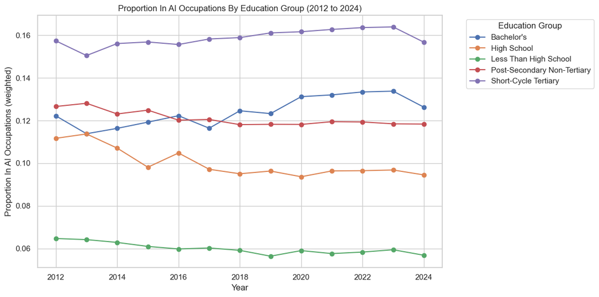

```
Key Points From Yearly Trend (2012 to 2024):
- Bachelor's: 12.22% in 2012 and 12.63% in 2024; Change between these years = 0.41%
- High School: 11.17% in 2012 and 9.45% in 2024; Change between these years = -1.72%
- Less Than High School: 6.47% in 2012 and 5.69% in 2024; Change between these years = -0.79%
- Post-Secondary Non-Tertiary: 12.66% in 2012 and 11.84% in 2024; Change between these years = -0.82%
- Short-Cycle Tertiary: 15.74% in 2012 and 15.68% in 2024; Change between these years = -0.06%
```

```python
# Create filtered datasets with positive survey weights only
lfs_pos = lfs[lfs['FINALWT'] > 0].copy()
lfs_ai_pos = lfs_ai[lfs_ai['FINALWT'] > 0].copy()

# Total weighted employment (all occupations)
total_w = (
    lfs_pos
    .groupby(['SURVYEAR', 'EDUC_GROUP'], as_index=False)['FINALWT']
    .sum()
    .rename(columns={'FINALWT': 'Total_Weighted'})
)

# Total weighted employment in AI-related occupations
ai_w = (
    lfs_ai_pos
    .groupby(['SURVYEAR', 'EDUC_GROUP'], as_index=False)['FINALWT']
    .sum()
    .rename(columns={'FINALWT': 'AI_Weighted'})
)

# Merge total employment and AI employment into a single table
yearly = pd.merge(total_w, ai_w, on=['SURVYEAR', 'EDUC_GROUP'], how='left')

# Replace missing AI values with zero (no AI employment in that group/year)
yearly['AI_Weighted'] = yearly['AI_Weighted'].fillna(0)

# Compute proportion of workers in AI-related occupations
yearly['Proportion_in_AI'] = yearly['AI_Weighted'] / yearly['Total_Weighted']

# Create a working copy used for reporting and plotting
representation = yearly.copy()

# Display yearly weighted representation table
print("\nYearly Representation By Education (weighted):")
display(
    representation
    .sort_values(['SURVYEAR', 'EDUC_GROUP'])
    .reset_index(drop=True)
    .head(10)
)

# Pivot data to wide format for trend plotting
trend = representation.pivot(index='SURVYEAR', columns='EDUC_GROUP', values='Proportion_in_AI')

# Line plot showing yearly trends of AI representation by education level (2012 to 2024)
ax = trend.plot(marker='o', figsize=(12,6))
ax.set_ylabel('Proportion In AI Occupations (weighted)')
ax.set_xlabel('Year')
ax.set_title('Proportion In AI Occupations By Education Group (2012 to 2024)')
ax.legend(title='Education Group', bbox_to_anchor=(1.05, 1), loc='upper left')
plt.tight_layout()
plt.show()

# Summarize key changes from 2012 to 2024
print("\nKey Points From Yearly Trend (2012 to 2024):")
for group in representation['EDUC_GROUP'].unique():
    df_group = representation[representation['EDUC_GROUP'] == group]

    # Compare AI representation in 2012 and 2024
    first_year = df_group.loc[df_group['SURVYEAR'] == 2012, 'Proportion_in_AI'].values[0]
    last_year = df_group.loc[df_group['SURVYEAR'] == 2024, 'Proportion_in_AI'].values[0]
    change = last_year - first_year
    print(f"- {group}: {first_year:.2%} in 2012 and {last_year:.2%} in 2024; Change between these years = {change:.2%}")
```

The trend plot shows how representation in AI-related occupations has shifted across education levels from 2012 to 2024 using weighted proportions. Workers with short-cycle tertiary education consistently remain the most represented group, staying close to 16% throughout the entire period with little change. In contrast, representation among those with post-secondary non-tertiary and high school education gradually declines, with high school graduates experiencing the most noticeable drop, from around 11% to just under 10%. Individuals with less than a high school education remain the least represented group from start to finish, decreasing slightly over time. Meanwhile, those with a bachelor’s degree show a small overall increase, rising from about 12.2% to 12.6% despite a slight dip near the end.

Overall, the results suggest that higher education, particularly short-cycle tertiary and bachelor’s education, continues to play a strong role in AI-related work, while representation among lower education groups has declined over the past decade. These patterns are also consistent with the key findings, which show small increases for those with a bachelor's degree and slight declines for most other groups between 2012 and 2024.

## EDA and Summary Analysis: Average AI Representation by Education Level

This section extends the exploratory analysis by summarizing AI-related employment representation across the entire study period. By calculating the average annual proportion of workers employed in AI-related occupations for each education group between 2012 and 2024, we move from year-specific exploration to a more aggregated analytical perspective.

The resulting table and bar chart provide a clear comparison of average representation levels across education groups. These visualizations make it easier to explore the data and highlight consistent differences in AI-related employment by education level. The summary analysis complements the yearly trends by emphasizing long-term patterns instead of short-term fluctuations.

```
Average Yearly Representation By Education (2012 to 2024):
```

|  | Education Group | Average Annual Proportion |
| --- | --- | --- |
| 0 | Short-Cycle Tertiary | 0.158734 |
| 1 | Bachelor's | 0.124238 |
| 2 | Post-Secondary Non-Tertiary | 0.121056 |
| 3 | High School | 0.100156 |
| 4 | Less Than High School | 0.059986 |

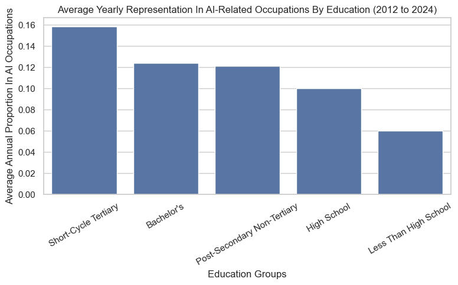

```
Key Points (Average Of Yearly Proportions, 2012 to 2024):
- Short-Cycle Tertiary: Average annual AI proportion = 15.87%
- Bachelor's: Average annual AI proportion = 12.42%
- Post-Secondary Non-Tertiary: Average annual AI proportion = 12.11%
- High School: Average annual AI proportion = 10.02%
- Less Than High School: Average annual AI proportion = 6.00%
```

```python
# Calculate the average annual proportion of workers in AI occupations for each education group
# This summarizes the yearly trends into one value for each education group
avg_annual = (
    representation
    .groupby('EDUC_GROUP', as_index=False)['Proportion_in_AI']
    .mean()
    .rename(columns={'Proportion_in_AI': 'Avg_Annual_Proportion'})
)

# Sort the results by average proportion in descending order for easier interpretation
avg_table_sorted = avg_annual.sort_values('Avg_Annual_Proportion', ascending=False).reset_index(drop=True)

# Rename columns for nicer labels
avg_table_sorted = avg_table_sorted.rename(
    columns={
        'EDUC_GROUP': 'Education Group',
        'Avg_Annual_Proportion': 'Average Annual Proportion'
    }
)

# Display the table to show average AI representation by education group
print("Average Yearly Representation By Education (2012 to 2024):")
display(avg_table_sorted)

# Create a bar plot to visualize average yearly AI representation by education group
plt.figure(figsize=(8,5))
sns.barplot(data=avg_table_sorted, x='Education Group', y='Average Annual Proportion')
plt.ylabel('Average Annual Proportion In AI Occupations')
plt.xlabel('Education Groups')
plt.title('Average Yearly Representation In AI-Related Occupations By Education (2012 to 2024)')
plt.xticks(rotation=30)
plt.tight_layout()
plt.show()

# Summarize key insights
print("\nKey Points (Average Of Yearly Proportions, 2012 to 2024):")
for _, row in avg_table_sorted.iterrows():
    print(f"- {row['Education Group']}: Average annual AI proportion = {row['Average Annual Proportion']:.2%}")
```

The bar plot shows the average yearly share of AI-related workers by education level from 2012 to 2024. Workers with short-cycle tertiary education have the highest representation, averaging 15.87% over the period. They are followed by those with a bachelor’s degree at 12.42% and post-secondary non-tertiary education at 12.11%. In contrast, high school graduates account for a smaller share at 10.02%, while individuals with less than a high school education remain the least represented, averaging just 6.00%.

These results indicate that AI-related employment is dominated by higher education levels, particularly workers with short-cycle tertiary and bachelor’s education. Lower representation of high school and less than high school groups indicates that AI jobs are mostly held by individuals with post-secondary education.

## Main Findings/Conclusions

The analysis of AI-related employment from 2012 to 2024 shows clear differences in representation across education levels. The following summarizes the main trends in AI-related employment across education levels from 2012 to 2024:

- **Those with short-cycle tertiary education** remain the most represented in AI occupations, averaging around 15–16% throughout the period.
- **Bachelor’s degree holders** show a moderate but steady representation, with a slight increase from 12.2% to 12.6% over the years, averaging 12.4%.
- **Those with post-secondary non-tertiary and high school education** experience gradual declines in AI representation, with high school graduates showing the largest drop, from roughly 11% to just under 10%.
- **Individuals with less than a high school education** remain the least represented group, averaging only 6% and showing a small decline over time.

Overall, these findings indicate that AI-related employment is concentrated among individuals with higher education, particularly short-cycle tertiary and bachelor’s degrees. Representation among lower education groups has generally decreased over the past decade, highlighting the strong influence of post-secondary education on access to AI occupations.